# Data With Tidyverse

MITCH

## Join the two data sets together

```r
# Join both data frames
ilo_data <- ilo_hourly_compensation %>%
  inner_join(ilo_working_hours, by = c("country", "year"))
# Count the resulting rows
ilo_data  %>%
    count()
```

```
## # A tibble: 1 x 1
##       n
##   <int>
## 1   612
```

```r
# Examine ilo_data
ilo_data
```

```
##     X.1.x X.x          country year hourly_compensation X.1.y X.y
## 1       1   1        Australia 1980                8.44     1   1
## 2       4   4           Canada 1980                8.87     2   2
## 3       5   5          Denmark 1980               10.83     3   3
## 4       6   6          Finland 1980                8.61     4   4
## 5       7   7           France 1980                8.90     5   5
## 6      12  12            Italy 1980                8.09     7   7
## 7      13  13            Japan 1980                5.46     8   8
## 8      14  14      Korea, Rep. 1980                0.95     9   9
## 9      19  19           Norway 1980               11.80    10  10
## 10     22  22            Spain 1980                5.86    11  11
## 11     24  24           Sweden 1980               12.40    12  12
## 12     25  25      Switzerland 1980               10.96    13  13
## 13     27  27   United Kingdom 1980                7.52    14  14
## 14     28  28    United States 1980                9.63    15  15
```

[output cut: 1211 more lines]

## Change variable types

```r
# Turn year into a factor
ilo_data <- ilo_data %>%
  mutate(year = as.factor(as.numeric(year)))

# Turn country into a factor
ilo_data <- ilo_data %>%
  mutate(country = as.factor(country))
```

## Filter the data for plotting

```r
# Examine the European countries vector
european_countries <- c("Finland"     ,   "France"      ,   "Italy"       ,   "Norway"   ,
 "Spain"     ,     "Sweden"      ,   "Switzerland"   , "United Kingdom",
  "Belgium"     ,   "Ireland"  ,      "Luxembourg"   ,  "Portugal"  ,
 "Netherlands" ,  "Germany"   ,   "Hungary"   ,   "Austria"  , "Czech Rep")

# Only retain European countries
ilo_data <- ilo_data %>%
  filter(country %in% european_countries)
ilo_data
```

```
##     X.1.x X.x        country year hourly_compensation X.1.y X.y
## 1       6   6        Finland 1980                8.61     4   4
## 2       7   7         France 1980                8.90     5   5
## 3      12  12          Italy 1980                8.09     7   7
## 4      19  19         Norway 1980               11.80    10  10
## 5      22  22          Spain 1980                5.86    11  11
## 6      24  24         Sweden 1980               12.40    12  12
## 7      25  25    Switzerland 1980               10.96    13  13
## 8      27  27 United Kingdom 1980                7.52    14  14
## 9      34  34        Finland 1981                8.33    19  19
## 10     35  35         France 1981                7.98    20  20
## 11     40  40          Italy 1981                7.52    22  22
## 12     47  47         Norway 1981               11.21    25  25
## 13     50  50          Spain 1981                5.52    26  26
## 14     52  52         Sweden 1981               11.70    27  27
```

[output cut: 723 more lines]

## Some summary statistics

```r
# Examine the structure of ilo_data
str(ilo_data)
```

```
## 'data.frame':    368 obs. of  8 variables:
##  $ X.1.x              : int  6 7 12 19 22 24 25 27 34 35 ...
##  $ X.x                : int  6 7 12 19 22 24 25 27 34 35 ...
##  $ country            : Factor w/ 30 levels "Australia","Austria",..: 8 9 15 22 25 27 28 29 8 9 ...
##  $ year               : Factor w/ 27 levels "1980","1981",..: 1 1 1 1 1 1 1 1 2 2 ...
##  $ hourly_compensation: num  8.61 8.9 8.09 11.8 5.86 ...
##  $ X.1.y              : int  4 5 7 10 11 12 13 14 19 20 ...
##  $ X.y                : int  4 5 7 10 11 12 13 14 19 20 ...
##  $ working_hours      : num  35.6 35.4 35.7 30.4 36.8 ...
```

```r
# Group and summarize the data
ilo_data %>%
  group_by(year) %>%
  summarize(mean_hourly_compensation = mean(hourly_compensation),
            mean_working_hours = mean(working_hours))
```

```
## # A tibble: 27 x 3
##    year  mean_hourly_compensation mean_working_hours
##    <fct>                    <dbl>              <dbl>
##  1 1980                      9.27               34.0
##  2 1981                      8.69               33.6
##  3 1982                      8.36               33.5
##  4 1983                      7.81               33.9
##  5 1984                      7.54               33.7
##  6 1985                      7.79               33.7
##  7 1986                      9.70               34.0
##  8 1987                     12.1                33.6
##  9 1988                     13.2                33.7
## 10 1989                     13.1                33.5
## # ... with 17 more rows
```

## A basic scatter plot

```r
# Filter for 2006
plot_data <- ilo_data %>%
  filter(year == 2006)

# Create the scatter plot
plot_data
```

```
##    X.1.x X.x        country year hourly_compensation X.1.y X.y
## 1    800 800        Austria 2006               30.46   687 687
## 2    801 801        Belgium 2006               31.85   688 688
## 3    806 806        Finland 2006               29.90   692 692
## 4    807 807         France 2006               24.90   693 693
## 5    808 808        Germany 2006               34.21   694 694
## 6    811 811        Hungary 2006                6.29   695 695
## 7    812 812        Ireland 2006               25.96   697 697
## 8    814 814          Italy 2006               25.07   698 698
## 9    817 817     Luxembourg 2006               27.74   701 701
## 10   819 819    Netherlands 2006               32.34   703 703
## 11   821 821         Norway 2006               41.05   705 705
## 12   824 824       Portugal 2006                7.65   707 707
## 13   826 826          Spain 2006               18.83   709 709
## 14   827 827         Sweden 2006               31.80   710 710
```

[output cut: 19 more lines]

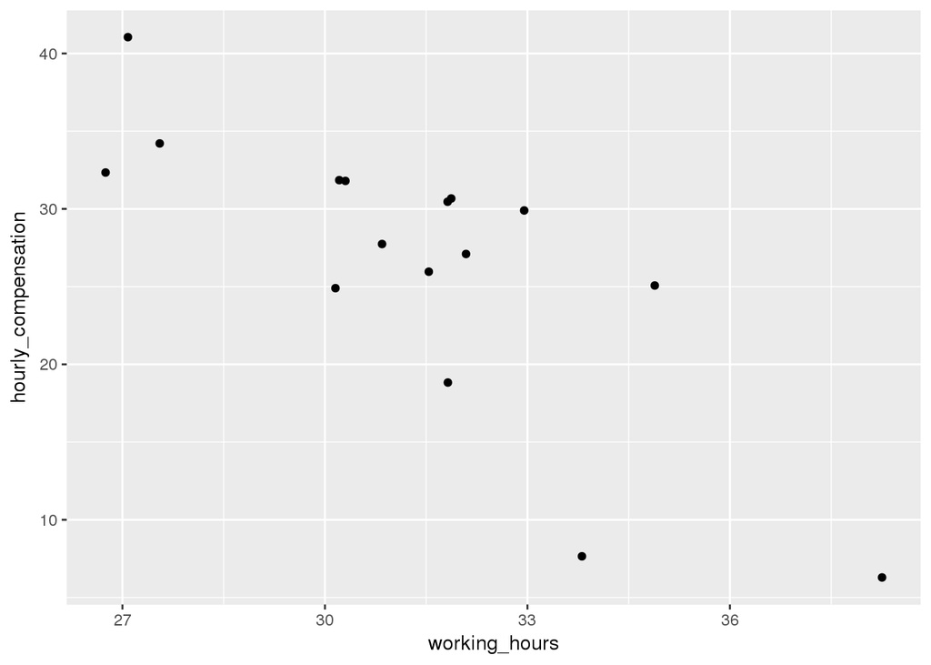

```r
ggplot(plot_data) +  geom_point(aes(x = working_hours, y = hourly_compensation))
```

## Add labels to the plot

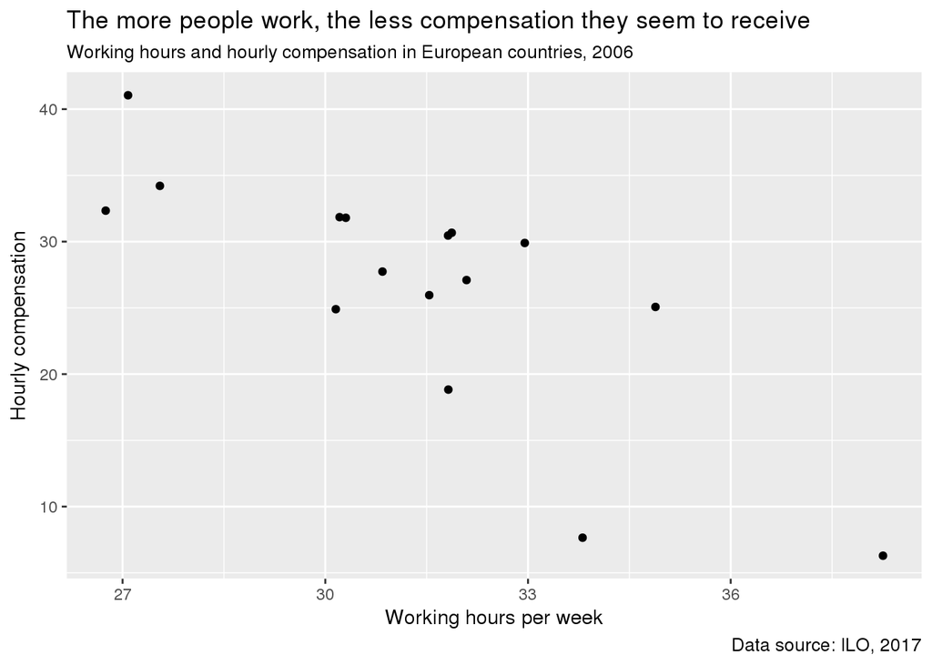

```r
# Create the plot
ggplot(plot_data) +
  geom_point(aes(x = working_hours, y = hourly_compensation)) +
  # Add labels
  labs(
    x = "Working hours per week",
    y = "Hourly compensation",
    title = "The more people work, the less compensation they seem to receive",
    subtitle = "Working hours and hourly compensation in European countries, 2006",
    caption = "Data source: ILO, 2017"
  )
```

## Apply a default theme

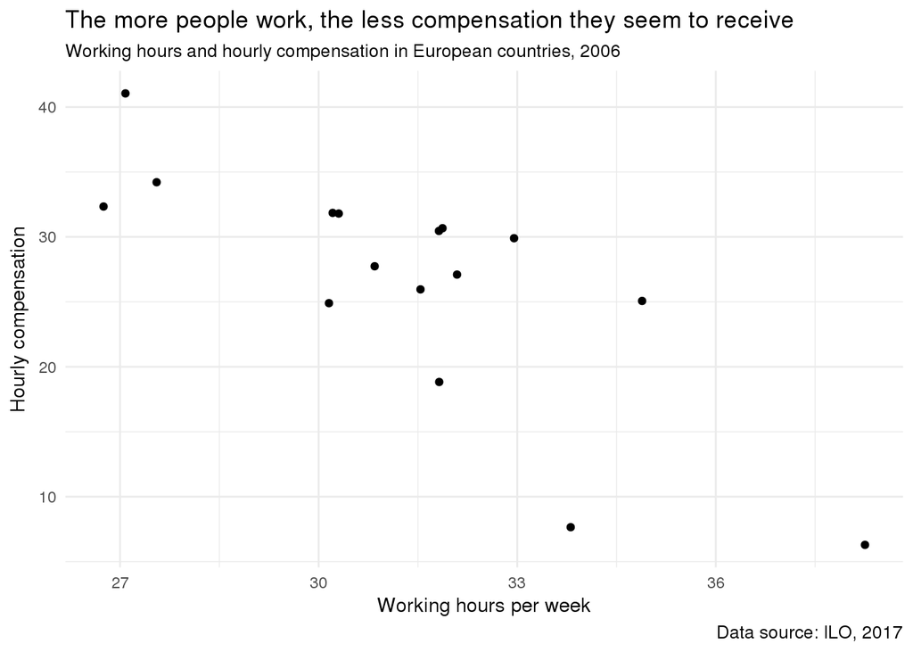

```r
# Save your current plot into a variable: ilo_plot
ilo_plot <- ggplot(plot_data) +
  geom_point(aes(x = working_hours, y = hourly_compensation)) +
  labs(
    x = "Working hours per week",
    y = "Hourly compensation",
    title = "The more people work, the less compensation they seem to receive",
    subtitle = "Working hours and hourly compensation in European countries, 2006",
    caption = "Data source: ILO, 2017"
  )

# Try out theme_minimal
ilo_plot +
  theme_minimal()
```

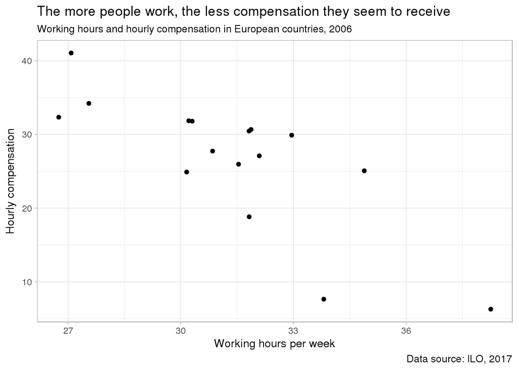

```r
# Try out any other possible theme function
ilo_plot +
  theme_light()
```

## Change the appearance of titles

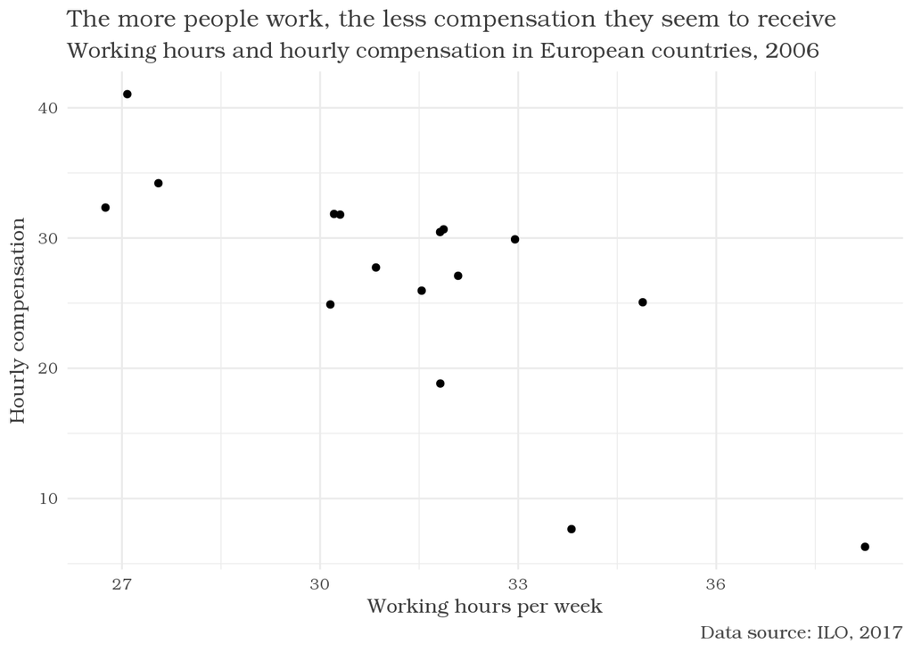

```r
ilo_plot <- ilo_plot +
  theme_minimal() +
  # Customize the "minimal" theme with another custom "theme" call
  theme(
    text = element_text(family = "Bookman"),
    title = element_text(color = "gray25"),
    plot.subtitle = element_text(size = 12),
    plot.caption = element_text(color = "gray30")
  )

# Render the plot object
ilo_plot
```

## Alter background color and add margins

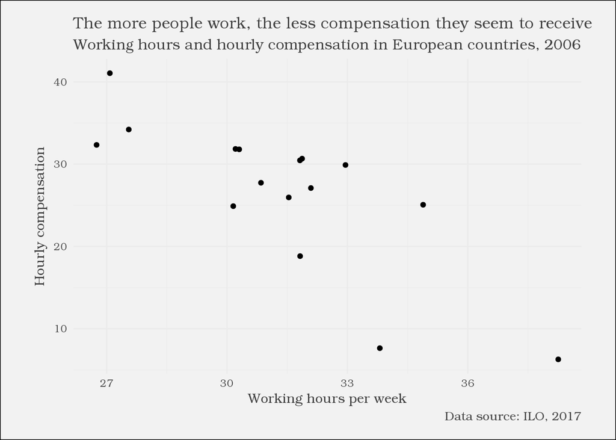

```r
ilo_plot +
  # "theme" calls can be stacked upon each other, so this is already the third call of "theme"
  theme(
    plot.background = element_rect(fill = "gray95"),
    plot.margin = unit(c(5, 10, 5, 10), units = "mm")
  )
```

## Prepare the data set for the faceted plot

```r
# Filter ilo_data to retain the years 1996 and 2006
ilo_data <- ilo_data %>%
  filter(year == "1996" | year == "2006")
```

## Add facets to the plot

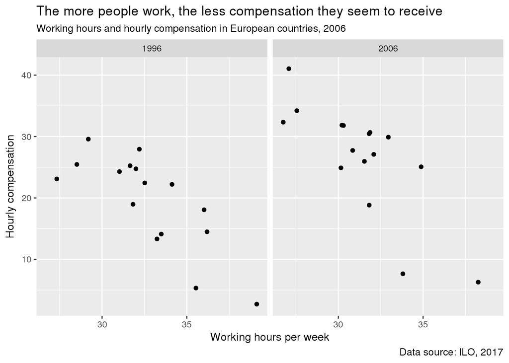

```r
# Again, you save the plot object into a variable so you can save typing later on
ilo_plot <- ggplot(ilo_data, aes(x = working_hours, y = hourly_compensation)) +
  geom_point() +
   labs(
    x = "Working hours per week",
    y = "Hourly compensation",
    title = "The more people work, the less compensation they seem to receive",
    subtitle = "Working hours and hourly compensation in European countries, 2006",
    caption = "Data source: ILO, 2017"
  ) +
  # Add facets here
  facet_grid(facets = . ~ year)

ilo_plot
```

## Define your own theme function

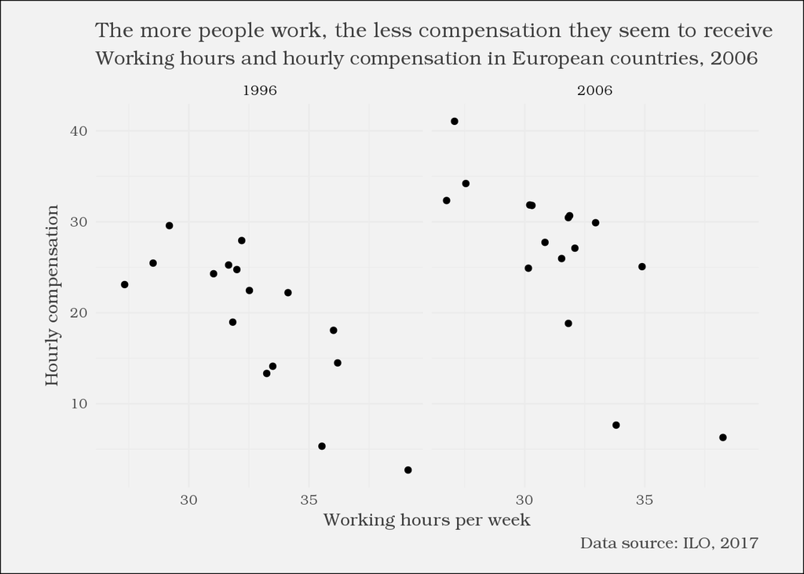

```r
# For a starter, let's look at what you did before: adding various theme calls to your plot object
ilo_plot +
  theme_minimal() +
  theme(
    text = element_text(family = "Bookman", color = "gray25"),
    plot.subtitle = element_text(size = 12),
    plot.caption = element_text(color = "gray30"),
    plot.background = element_rect(fill = "gray95"),
    plot.margin = unit(c(5, 10, 5, 10), units = "mm")
  )
```

```r
# Define your own theme function below
theme_ilo <- function() {
  theme_minimal() +
  theme(
    text = element_text(family = "Bookman", color = "gray25"),
    plot.subtitle = element_text(size = 12),
    plot.caption = element_text(color = "gray30"),
    plot.background = element_rect(fill = "gray95"),
    plot.margin = unit(c(5, 10, 5, 10), units = "mm")
  )
}
```

## Apply the new theme function to the plot

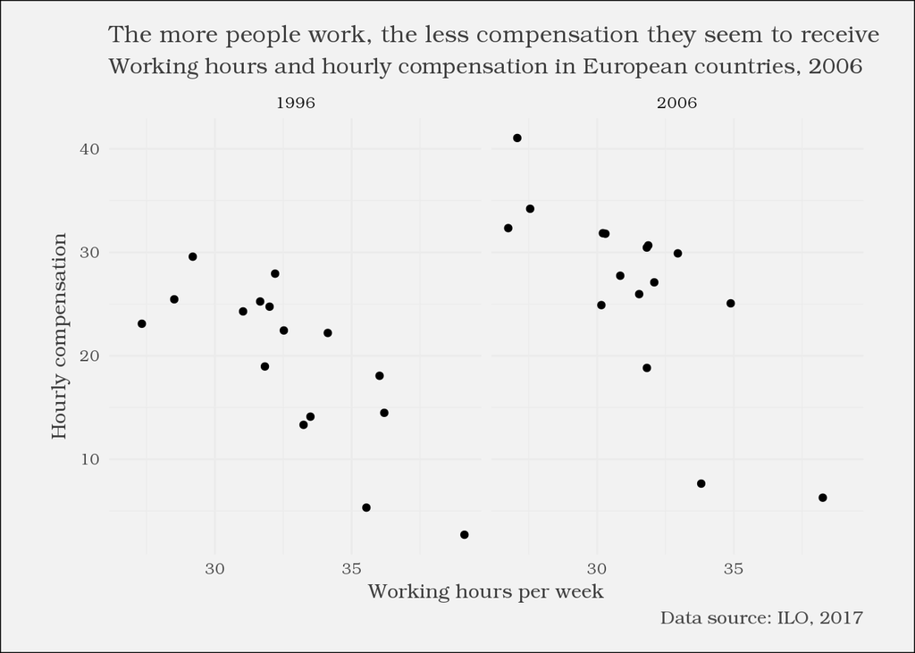

```r
# Apply your theme function
ilo_plot <- ilo_plot +
  theme_ilo()

# Examine ilo_plot
ilo_plot
```

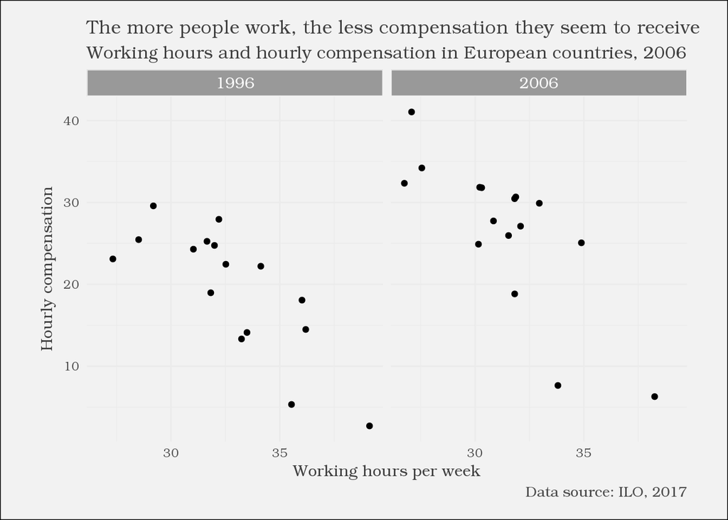

```r
ilo_plot +
   # Add another theme call
  theme(
    # Change the background fill to make it a bit darker
    strip.background = element_rect(fill = "gray60", color = "gray95"),
    # Make text a bit bigger and change its color
    strip.text = element_text(size = 11, color = "white")
  )
```

## A basic dot plot

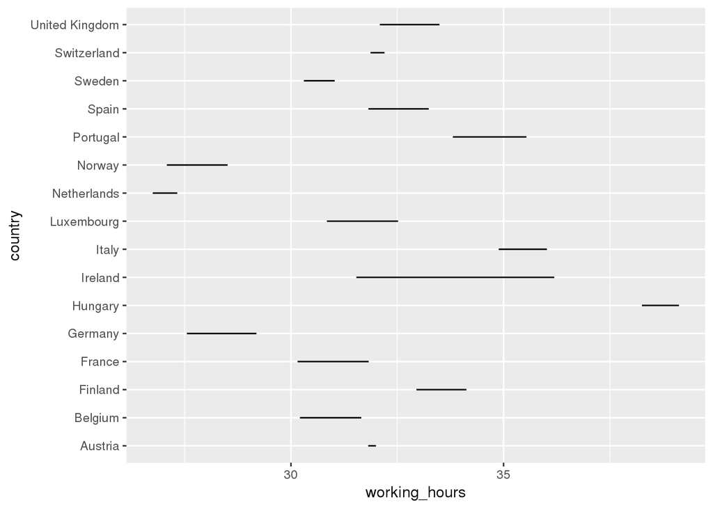

```r
# Create the dot plot
ggplot(ilo_data) +
  geom_path(aes(x = working_hours, y = country))
```

## Add arrows to the lines in the plot

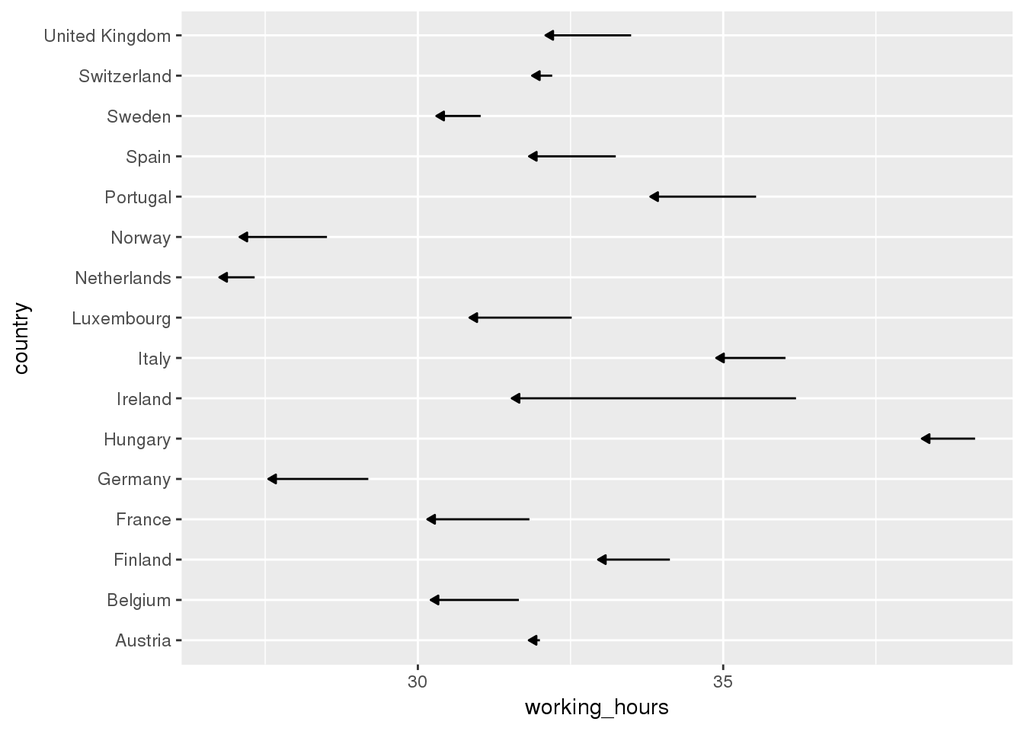

```r
ggplot(ilo_data) +
  geom_path(aes(x = working_hours, y = country),
  # Add an arrow to each path
            arrow = arrow(length = unit(1.5, "mm"), type = "closed"))
```

## Add some labels to each country

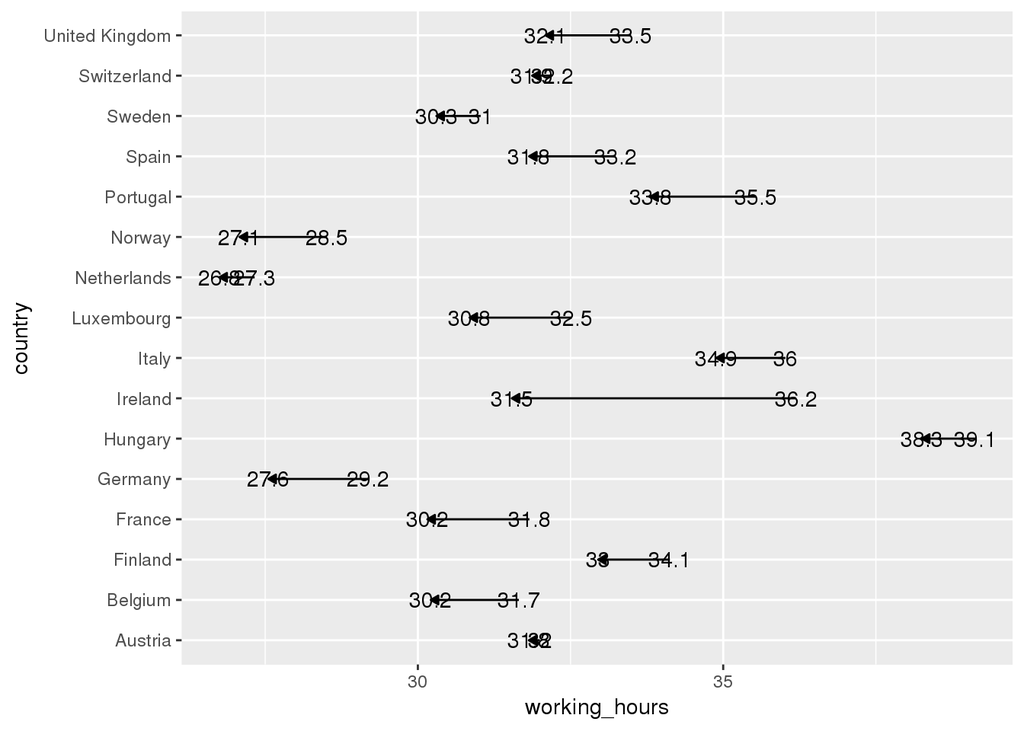

```r
ggplot(ilo_data) +
  geom_path(aes(x = working_hours, y = country),
            arrow = arrow(length = unit(1.5, "mm"), type = "closed")) +
  # Add a geom_text() geometry
  geom_text(
          aes(x = working_hours,
              y = country,
              label = round(working_hours, 1))
        )
```

## Reordering elements in the plot

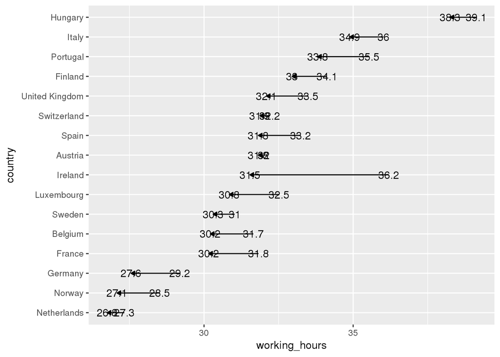

```r
library(forcats)

# Reorder country factor levels
ilo_data <- ilo_data %>%
  # Arrange data frame
  arrange(year) %>%
  # Reorder countries by working hours in 2006
  mutate(country = fct_reorder(country,
                               working_hours,
                               last))

# Plot again
ggplot(ilo_data) +
  geom_path(aes(x = working_hours, y = country),
            arrow = arrow(length = unit(1.5, "mm"), type = "closed")) +
    geom_text(
          aes(x = working_hours,
              y = country,
              label = round(working_hours, 1))
          )
```

## Correct ugly label positions

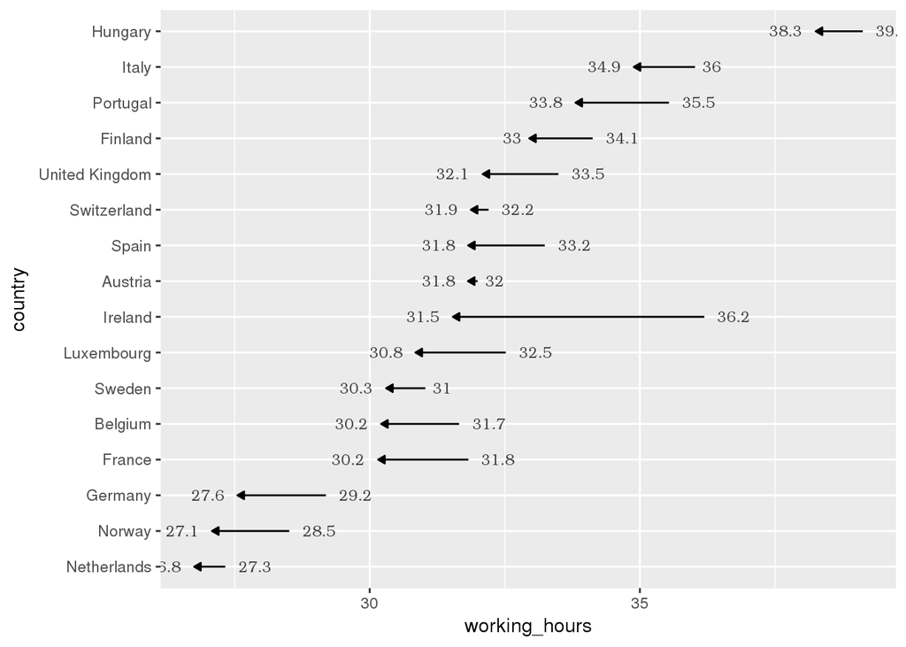

```r
# Save plot into an object for reuse
ilo_dot_plot <- ggplot(ilo_data) +
  geom_path(aes(x = working_hours, y = country),
            arrow = arrow(length = unit(1.5, "mm"), type = "closed")) +
    # Specify the hjust aesthetic with a conditional value
    geom_text(
          aes(x = working_hours,
              y = country,
              label = round(working_hours, 1),
              hjust = ifelse(year == "2006", 1.4, -0.4)
            ),
          # Change the appearance of the text
          size = 3,
          family = "Bookman",
          color = "gray25"
          )

ilo_dot_plot
```

## Change the viewport so labels don’t overlap with plot border

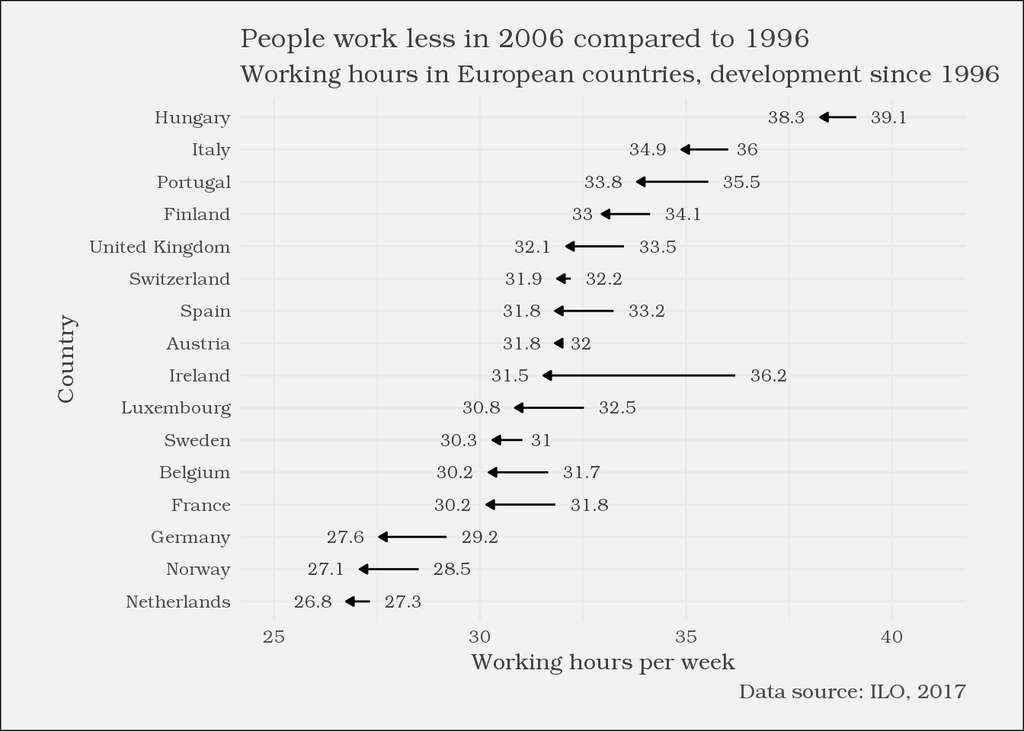

```r
# Reuse ilo_dot_plot
ilo_dot_plot <- ilo_dot_plot +
  # Add labels to the plot
  labs(
    x = "Working hours per week",
    y = "Country",
    title = "People work less in 2006 compared to 1996",
    subtitle = "Working hours in European countries, development since 1996",
    caption = "Data source: ILO, 2017"
  ) +
  # Apply your theme
  theme_ilo() +
  # Change the viewport
  coord_cartesian(xlim = c(25, 41))

# View the plot
ilo_dot_plot
```

## Optimizing the plot for mobile devices

```r
# Compute temporary data set for optimal label placement
median_working_hours <- ilo_data %>%
  group_by(country) %>%
  summarize(median_working_hours_per_country = median(working_hours)) %>%
  ungroup()

# Have a look at the structure of this data set
str(median_working_hours)
```

```
## Classes 'tbl_df', 'tbl' and 'data.frame':    16 obs. of  2 variables:
##  $ country                         : Factor w/ 30 levels "Netherlands",..: 1 2 3 4 5 6 7 8 9 10 ...
##  $ median_working_hours_per_country: num  27 27.8 28.4 31 30.9 ...
```

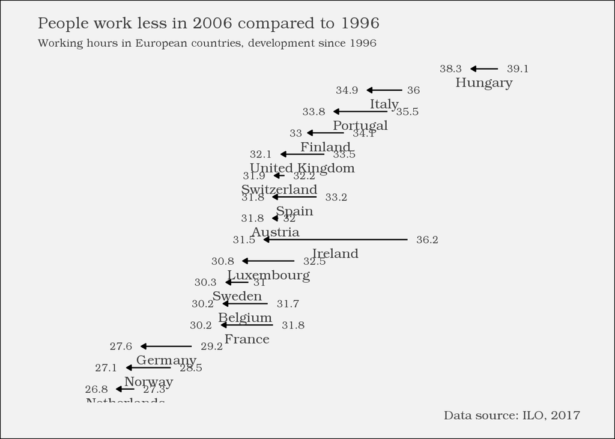

```r
ilo_dot_plot +
  # Add label for country
  geom_text(data = median_working_hours,
            aes(y = country,
                x = median_working_hours_per_country,
                label = country),
            vjust = 2,
            family = "Bookman",
            color = "gray25") +
  # Remove axes and grids
  theme(
    axis.ticks = element_blank(),
    axis.title = element_blank(),
    axis.text = element_blank(),
    panel.grid = element_blank(),
    # Also, let's reduce the font size of the subtitle
    plot.subtitle = element_text(size = 9)
  )
```

## Introduction to the RMarkdown exercise interface

```
---
title: "Communicating with Data in the Tidyverse"
author: "DataCamp"
date: "March 2018"
output: html_document
---
```

The following plot shows the relationship between the number of cylinders and miles per gallon in the `mtcars` dataset.

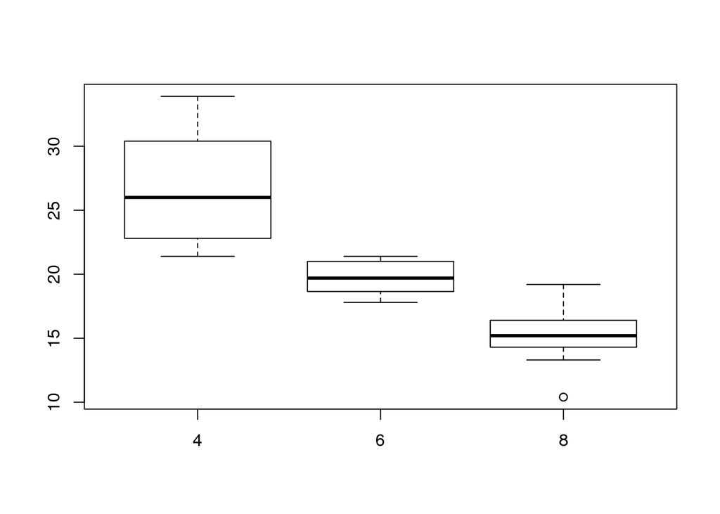

```r
boxplot(mtcars$mpg ~ mtcars$cyl)
```

As one can see, the more cylinders, the less miles per gallons.

## Give your document a structure

```
---
title: "The reduction in weekly working hours in Europe"
subtitle: "Looking at the development between 1996 and 2006"
author: "Insert your name here"
output: html_document
---
```

### Summary

This is where you are going to quickly summarize what you did.

### Preparations

This is where you will load the necessary R packages.

### Analysis

#### Data

This is where you will load the data.

#### Preprocessing

This is where you will preprocess the data.

#### Results

This is where you will plot the data.

## Change formatting of text snippets

```
---
title: "The reduction in weekly working hours in Europe"
subtitle: "Looking at the development between 1996 and 2006"
author: "Mitch Holman"
output: html_document
---
```

### Summary

The **International Labour Organization** (ILO) has many [data sets](http://www.ilo.org/global/statistics-and-databases/lang--en/index.htm) on working conditions. For example, one can look at how weekly working hours have been decreasing in many countries of the world, while monetary compensation has risen. In this report, *the reduction in weekly working hours* in European countries is analysed, and a comparison between 1996 and 2006 is made. All analysed countries have seen a decrease in weekly working hours since 1996 – some more than others.

### Preparations

This is where you will load the necessary R packages.

### Analysis

#### Data

This is where you will load the data.

#### Preprocessing

This is where you will preprocess the data.

### Results

This is where you will plot the data.

## Specify packages in the first code chunk

```
---
title: "The reduction in weekly working hours in Europe"
subtitle: "Looking at the development between 1996 and 2006"
author: "Insert your name here"
output: html_document
---
```

## R code chunk options

```
---
title: "The reduction in weekly working hours in Europe"
subtitle: "Looking at the development between 1996 and 2006"
author: "Insert your name here"
output: html_document
---
```

## Inline code statements

```
---
title: "The reduction in weekly working hours in Europe"
subtitle: "Looking at the development between 1996 and 2006"
author: "Insert your name here"
output: html_document
---
```

## Add auxiliary images

```
---
title: "The reduction in weekly working hours in Europe"
subtitle: "Looking at the development between 1996 and 2006"
author: "Insert your name here"
output: html_document
---
```

## Change the overall appearance of your report

```
---
title: "The reduction in weekly working hours in Europe"
subtitle: "Looking at the development between 1996 and 2006"
author: "Insert your name here"
output:
  html_document:
    theme: cosmo
    highlight: monochrome
---
```

## Add a table of contents

```
---
title: "The reduction in weekly working hours in Europe"
subtitle: "Looking at the development between 1996 and 2006"
author: "Insert your name here"
output:
  html_document:
    theme: cosmo
    highlight: monochrome
    toc: true
    toc_float: false
    toc_depth: 4
---
```

## More YAML hacks

```
---
title: "The reduction in weekly working hours in Europe"
subtitle: "Looking at the development between 1996 and 2006"
author: "Insert your name here"
output:
  html_document:
    theme: cosmo
    highlight: monochrome
    toc: true
    toc_float: false
    toc_depth: 4
    number_sections: true
    code_folding: hide
---
```

## Change style attributes of text elements

```
---
title: "The reduction in weekly working hours in Europe"
subtitle: "Looking at the development between 1996 and 2006"
author: "Insert your name here"
output:
  html_document:
    theme: cosmo
    highlight: monochrome
    toc: true
    toc_float: false
    toc_depth: 4
    code_folding: hide
---
```

## Reference the style sheet

```
---
title: "The reduction in weekly working hours in Europe"
subtitle: "Looking at the development between 1996 and 2006"
author: "Insert your name here"
output:
  html_document:
    theme: cosmo
    highlight: monochrome
    toc: true
    toc_float: false
    toc_depth: 4
    code_folding: hide
    css: styles.css
---
```

## Beautify a table with kable

```
---
title: "The reduction in weekly working hours in Europe"
subtitle: "Looking at the development between 1996 and 2006"
author: "Insert your name here"
output:
  html_document:
    theme: cosmo
    highlight: monochrome
    toc: true
    toc_float: false
    toc_depth: 4
    code_folding: hide
    css: styles.css
    df_print: kable
---
```